# Data Cleaning

Michal

2024-07-02

# Data Set

```r
bots = read.csv("C:/Users/Owner/Desktop/Data Science Project/Twitter-Bot-Code/archive/twitter_human_bots_dataset.csv")
```

```r
head(bots)
```

```
##   X          created_at default_profile default_profile_image
## 1 0 2009-07-04 22:41:51           False                 False
## 2 1 2010-01-17 22:54:19           False                 False
## 3 2 2012-03-01 06:05:32           False                 False
## 4 3 2009-09-01 04:52:30           False                 False
## 5 4 2010-01-27 17:17:23           False                 False
## 6 5 2017-06-17 05:45:14            True                 False
##                                                                                                                                    description
## 1
## 2                                                       Television producer. Emmy Award winner. Disney enthusiast. ZBB followers. Kitty crazy.
## 3
## 4
## 5 Productor de Televisión - Embajador de @TiendasEnForma y @NewLabNutrition Contacto: dream@davidhenaofilms.com \nInstagram: davidhenaofitness
## 6
##   favourites_count followers_count friends_count geo_enabled           id lang
```

[output cut: 48 more lines]

# Data Profiling

## Missing Data

```r
nrow(bots)
```

```
## [1] 37438
```

```r
bots_without_na = bots %>%
  drop_na()
nrow(bots_without_na)
```

```
## [1] 37438
```

```r
empty_char = bots %>%
  filter(str_trim(created_at)== "" | str_trim(default_profile) == "" | str_trim(default_profile_image) == "" | str_trim(geo_enabled) == ""  |  str_trim(screen_name) == "" | str_trim(verified) == "" | str_trim(account_type) == "" )
nrow(empty_char)
```

```
## [1] 0
```

```r
empty_char = bots %>%
  filter(str_trim(description) == "")
nrow(empty_char)
```

```
## [1] 7256
```

```r
empty_char = bots %>%
  filter(str_trim(lang) == "")
nrow(empty_char)
```

```
## [1] 7957
```

```r
empty_char = bots %>%
  filter(str_trim(location) == "")
nrow(empty_char)
```

```
## [1] 17
```

```r
empty_char = bots %>%
  filter(str_trim(location) == "unknown")
nrow(empty_char)
```

```
## [1] 13023
```

*Observations*

- No rows had NA values
- No char values except in description, lang, and location column are empty
- Empty counts: description-7256, lang-7957, location-17
- Location has 13023 values of “unknown”
- X is an index column
- Includes four columns linking to images

*Impact*

- It is reasonable that many accounts will not have a description, language, and location
- Standardize missing location values to “unknown”
- Remove X column because it is not useful
- Remove image related columns because we lack ability to analyze images

## Column Types

```r
class(bots$created_at)
```

```
## [1] "character"
```

```r
class(bots$default_profile)
```

```
## [1] "character"
```

```r
class(bots$default_profile_image)
```

```
## [1] "character"
```

```r
class(bots$description)
```

```
## [1] "character"
```

```r
class(bots$favourites_count)
```

```
## [1] "integer"
```

```r
class(bots$followers_count)
```

```
## [1] "integer"
```

```r
class(bots$friends_count)
```

```
## [1] "integer"
```

```r
class(bots$geo_enabled)
```

```
## [1] "character"
```

```r
class(bots$id)
```

```
## [1] "numeric"
```

```r
class(bots$lang)
```

```
## [1] "character"
```

```r
class(bots$location)
```

```
## [1] "character"
```

```r
class(bots$screen_name)
```

```
## [1] "character"
```

```r
class(bots$statuses_count)
```

```
## [1] "integer"
```

```r
class(bots$verified)
```

```
## [1] "character"
```

```r
class(bots$average_tweets_per_day)
```

```
## [1] "numeric"
```

```r
class(bots$account_age_days)
```

```
## [1] "integer"
```

```r
class(bots$account_type)
```

```
## [1] "character"
```

```r
class(bots$split)
```

```
## [1] "integer"
```

*Observations*

- created_at is a character
- default_profile is a character
- default_profile_image is a character
- geo_enabled is a character
- verified is a character
- account_type is a character

## Outliers

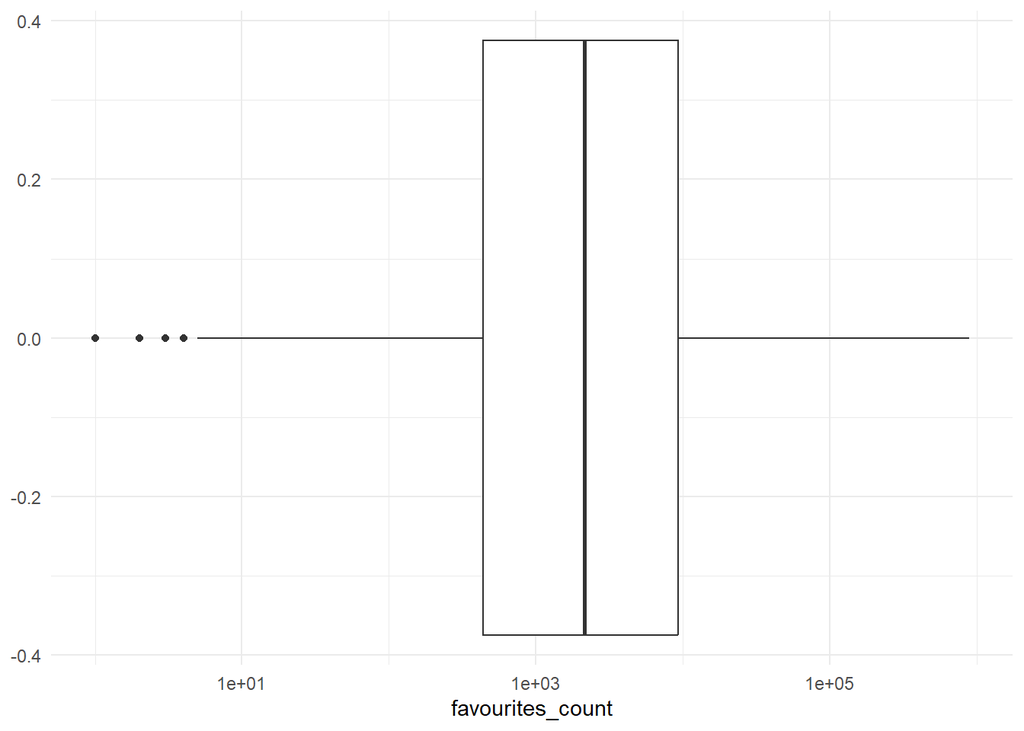

```r
ggplot(data = bots, mapping = aes(favourites_count))+
  geom_boxplot()+
  scale_x_log10()+
  theme_minimal()
```

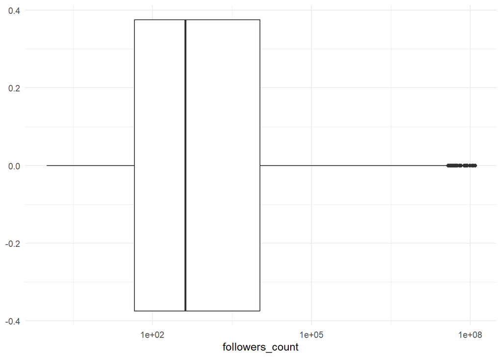

```r
ggplot(data = bots, mapping = aes(followers_count))+
  geom_boxplot()+
  scale_x_log10()+
  theme_minimal()
```

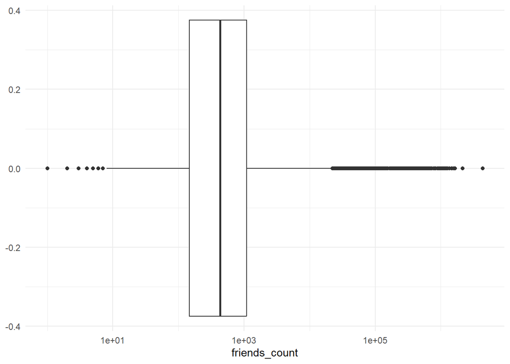

```r
ggplot(data = bots, mapping = aes(friends_count))+
  geom_boxplot()+
  scale_x_log10()+
  theme_minimal()
```

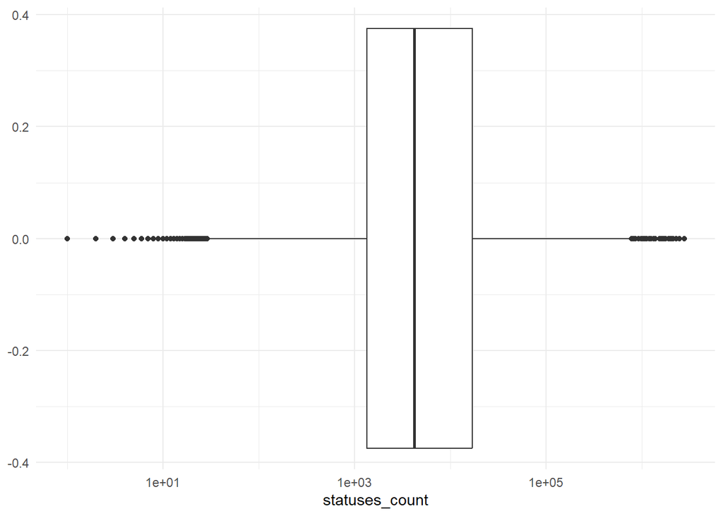

```r
ggplot(data = bots, mapping = aes(statuses_count))+
  geom_boxplot()+
  scale_x_log10()+
  theme_minimal()
```

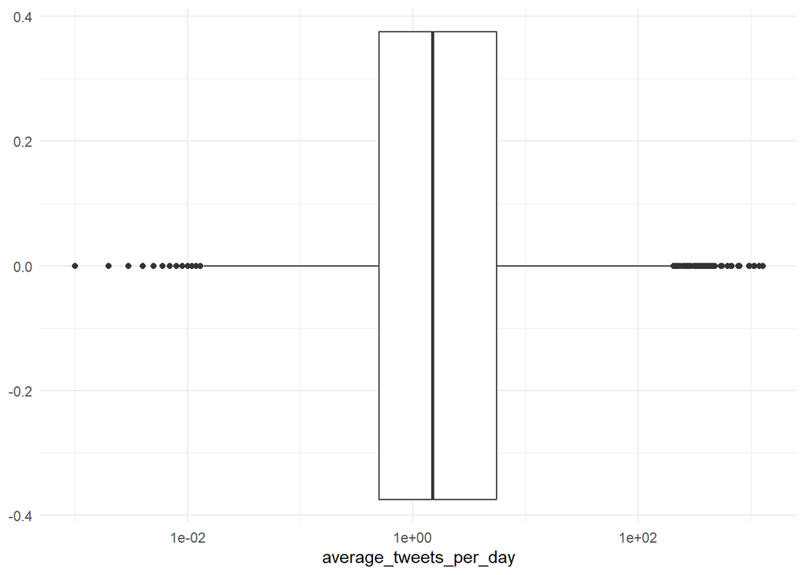

```r
ggplot(data = bots, mapping = aes(average_tweets_per_day))+
  geom_boxplot()+
  scale_x_log10()+
  theme_minimal()
```

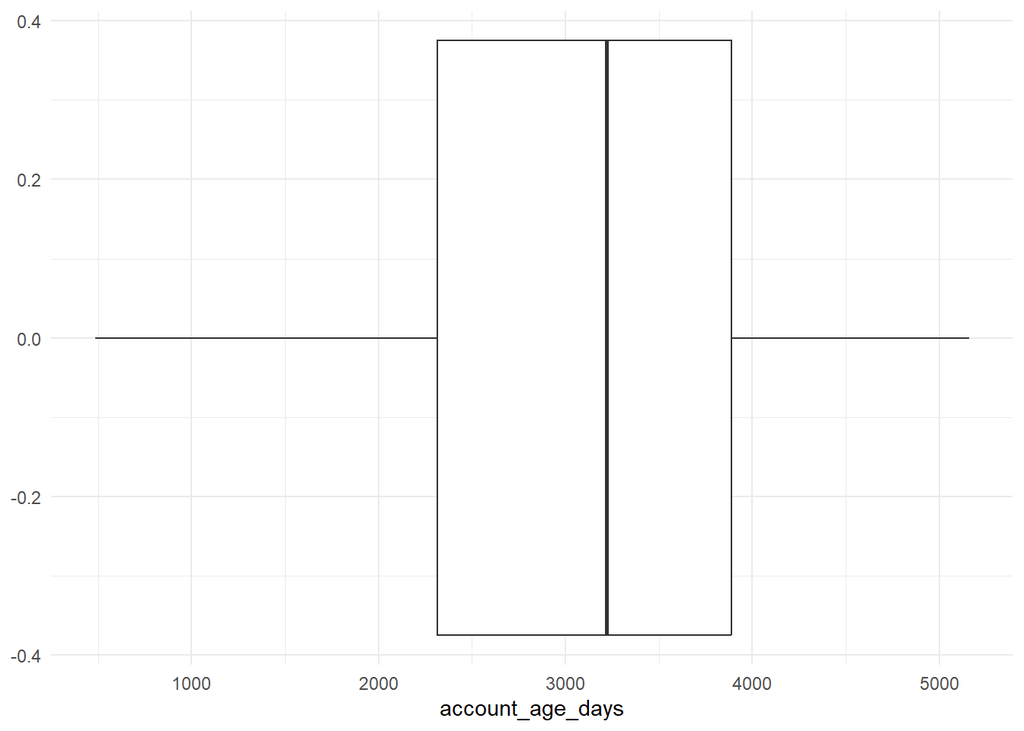

```r
ggplot(data = bots, mapping = aes(account_age_days))+
  geom_boxplot()+
  theme_minimal()
```

*Observations*

*Impact*

- Transform each of the skewed columns by taking log10
- Apply winsorizing to the transformed data

## Data Pre-processing Pipeline

Based on the anaylsis above, the following data cleaning and pre-processing steps will be taken:

- Standardize missing location values to “unknown”
- Remove X column because it is not useful
- Remove image related columns because we lack ability to analyze images
- Cast created_at to a date-time class for now
- Cast default_profile to boolean
- Cast default_profile_image to boolean
- Cast geo_enabled to boolean
- Cast verified to boolean
- Cast account_type to number (bot = 1) and change column name to “is_bot” (easier for logistic regression)
- Transform each of the skewed columns by taking log10
- Apply winsorizing to the transformed data

```r
cleaning_function = function(data) {
  cleaned = data%>%
    # remove unnecessary columns
    select(-X,-profile_image_path,-profile_background_image_path, -profile_background_image_url, -profile_image_url)%>%

     # standardize missing location  value
    mutate(
      location = if_else(str_trim(location) == "","unknown",location))%>%

    # type cast to correct class
  mutate(
    created_at = ymd_hms(created_at),
    default_profile = as.logical(default_profile),
    default_profile_image = as.logical(default_profile_image),
    geo_enabled = as.logical(geo_enabled),
    verified = as.logical(verified))%>%

     #cast and rename account_type
  mutate(
    account_type=if_else(account_type=="bot",1,0))%>%
  rename(is_bot=account_type)%>%

    # transform and winsorize outliers
    mutate(
      # log(x+1) to avoid "-inf"
      log_favourites_count = log10(favourites_count+1),
      log_followers_count = log10(followers_count+1),
      log_friends_count = log10(friends_count+1),
      log_statuses_count = log10(statuses_count+1),
      log_avg_tweets_per_day = log10(average_tweets_per_day+1)
    )%>%
    mutate(
      log_favourites_count= Winsorize(log_favourites_count),
      log_followers_count = Winsorize(log_followers_count),
      log_friends_count = Winsorize(log_friends_count),
      log_statuses_count = Winsorize(log_statuses_count),
      log_avg_tweets_per_day = Winsorize(log_avg_tweets_per_day)
    )%>%

  # remove old columns
  select(-favourites_count,-followers_count,-friends_count, -statuses_count, -average_tweets_per_day)
  return(cleaned)
}
```